# Epigenetic Age: Postprocessing Instructions

The MIND Consortium

2025-09-25

# Overview

This document describes the input requirements (methylation data and covariates) and provides a brief overview of the R script used to postprocess epigenetic data. Posprocessing is performed within **R**. Please ensure that you read the “Notes” section at the end of the document before running the script.

# Before Postprocessing

### Input requirements

- **Methylation data**
  - Preprocessed methylation data (ideally functionally normalised using MIND DNA methylation preprocessing scripts), stored as a separate `.rds` files **per time point and array**
  - Data format: `matrix` with **CpGs as rows** and **participant IDs as columns**:

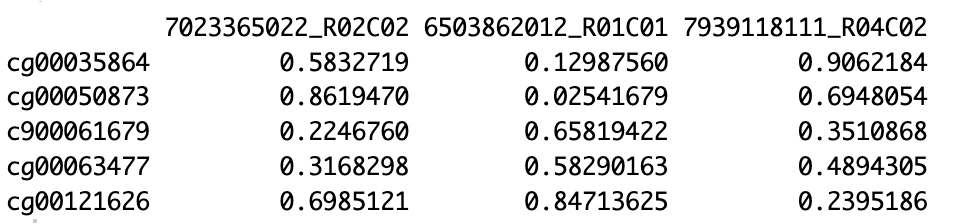

  > 💡 If functional normalisation is not feasible (e.g., data already processed differently), you may use existing data — but ensure it matches the required format.
- **Covariates (samplesheet)**
  - A simple file **per time point** with the following columns: `Sample_Name`, `age`, `sex`
  - Column names must match exactly. If additional columns are present, they will be ignored
    - **Age** should be in years for all time points. For **birth** time point, please convert gestational weeks to years using the following formula:

      ```r
      age = (7 * (gestational_weeks - 40)) / 365
      ```

    - **Sex** should be code as `"Female"` (or any string starting with `"F"`) and `"Male"` (or any string starting with `"M"`)
- **Suggested data structure** (as contained in the shared brain_epi folder)

  | Folder | Function |
  | --- | --- |
  | brain_epi | project directory |
  | brain_epi/epi | part of the project directory related to epi |
  | brain_epi/epi/raw | raw / unprocessed methylation data |
  | brain_epi/epi/preprocessed | processed epi data (result of step 1) |
  | brain_epi/epi/postprocessed | postprocessed epi data will be stored here |
  | brain_epi/epi/scripts | scripts for pre-process, epi models etc. |
  | brain_epi/epi/models | where the epi age model predictions are saved |
  | brain_epi/epi/descriptives_and_plots | Descriptives + plots from pre-processing |

# Postprocessing

Relates to scripts in *`brain_epi/epi/scripts` folder*

0. **Preliminary cleanup**
   - Retain one individual per sibling/twin pair and remove duplicate samples
   - Convert gestational age to years (if applicable)
   - Save separate **samplesheets** and **DNAm `.rds` files** per time point and array
   - Expected methylation data format: CpGs in rows, participant IDs in columns.
   - ⚠️ No script is provided for this step. Please follow procedures specific to your cohort.
   - Example: `2.0.postprocess-example-ALSPAC-specific.R`.
1. **Impute & winsorise DNAm data (R script)**
   - Run: `2.1.postprocess-DNAm-data.R`
   - ⏳ Note: may take several hours.

# What to send us

Please send us the generated descriptives and log files, located under

- /brain_epi/epi/postprocessed/descriptives/
- /brain_epi/epi/postprocessed/logs/

# Notes

- The `functions` folder contains custom helper functions. These are sourced automatically
- As long as your data is formatted correctly, **no edits to the functions are needed**
- Please share the `postprocessed/logs` and `postprocessed/descriptives` folder with us after completing the analysis (ms2290@bath.ac.uk, )
- ❗❗❗Before running the scripts, **always open each script and update**:
  - Working directory path (should point to the `brain_epi/epi` folder provided by us)
  - Dataset names
  - Time point names (e.g., birth/cord, 7 year, 15 year)
  - Array name (e.g., 450k or EPIC)